# Whale-Krill Comparison GAMs

2025-10-22

## 1. Load and prepare data

Load hourly passive acoustic detections, active acoustic krill swarm metrics, sea ice draft, and light (solar/lunar) data. Derive key variables used throughout the analysis.

```r
rm(list = ls())

# --- Libraries ----------------------------------------------------------------
library(mgcv)       # GAMs
library(ggplot2)    # plotting
library(tidyr)      # data reshaping
library(plotly)     # interactive plots
library(here)       # relative file paths
library(cluster)    # clustering
library(factoextra) # clustering visualisation
library(scales)     # axis formatting
library(viridis)    # colour palettes
library(patchwork)  # combining plots
library(gratia)     # GAM utilities
library(knitr)      # table formatting
library(ggpubr)     # publication-ready plots with stat comparisons
library(suncalc)    # sunrise/sunset times
library(ggh4x)      # per-facet axis scales

if (!require(purrr)) install.packages("purrr")
library(dplyr)      # data manipulation
```

```r
# --- File paths ---------------------------------------------------------------
#data_dir  <- "c:\\Users\\DCCEEW\\Documents\\AcousticPreyFieldSegregation-main\\"# "C:/Users/abbie_smi/OneDrive - Antarctic/Data/R/KOMBI03 whales/GAM - Brian/clean"
#func_path <- file.path(data_dir, "log-normCIs.R")
#dat_file  <- file.path(data_dir, "TT_align_swarm_regioncells.csv")

# Source log-normal confidence interval helper function
source(here::here('R', "log-normCIs.R"))

# --- Load data ----------------------------------------------------------------
#dat <- read.csv(dat_file)
dat<-read.csv(here::here('data','TT_align_swarm_regioncells.csv'))
# --- Time variables -----------------------------------------------------------
dat$timeStamp  <- as.POSIXct(dat$timeVec, format = "%Y-%m-%d %H:%M:%S", tz = "UTC")
#dat$timeStamp  <- as.POSIXct(dat$dt, format = "%d/%m/%Y %H:%M", tz = "UTC")

dat$hour       <- as.numeric(format(dat$timeStamp, "%H"))
dat$day_of_year <- as.numeric(format(dat$timeStamp, "%j"))
dat$month      <- as.integer(format(dat$timeStamp, "%m"))
summary(dat$day_of_year)
```

```
##    Min. 1st Qu.  Median    Mean 3rd Qu.    Max.
##     1.0    95.0   185.0   184.6   275.0   365.0
```

```r
# --- Krill presence-absence and density ---------------------------------------
# Binary krill presence (1 = detected, 0 = absent)
dat$krill_PA=0
dat$krill_PA[dat$rho_v>0]=1
table(dat$krill_PA)
```

```
##
##    0    1
## 5897 2745
```

```r
# Add half the minimum detectable density to avoid zeros in log/Gamma models
min_det    <- min(dat$rho_v[dat$krill_PA == 1])
dat$rho_min <- dat$rho_v + min_det / 2

# Max krill density diagnostics
max(dat$rho_v, na.rm = TRUE)
```

```
## [1] 2529.061
```

```r
dat$timeVec[which.max(dat$rho_v)]
```

```
## [1] "2021-09-04 10:00:00"
```

```r
dat$Center_of_mass[which.max(dat$rho_v)]
```

```
## [1] 382.6493
```

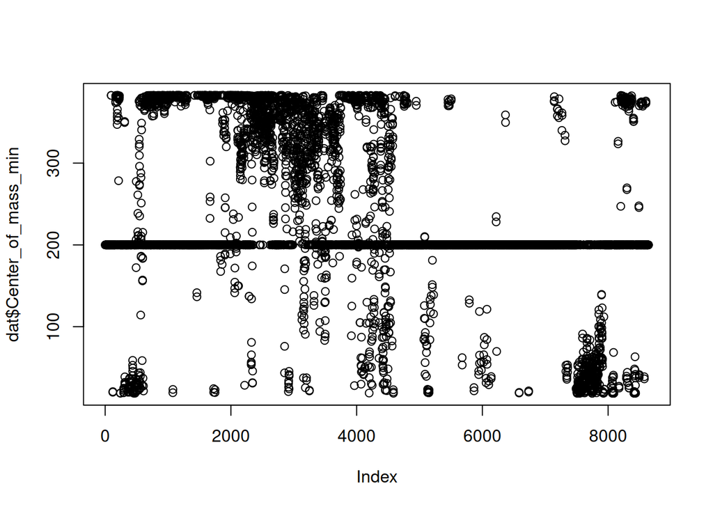

```r
# --- Centre of mass: replace NaN with background value of 200 m --------------
dat$Center_of_mass_min <- 200
dat$Center_of_mass_min[!is.nan(dat$Center_of_mass)] <-
  dat$Center_of_mass[!is.nan(dat$Center_of_mass)]
plot(dat$Center_of_mass_min)
```

```r
# --- Sea ice ------------------------------------------------------------------
# Convert ice variable to draft (m); negative values set to zero (open water)
dat$ice <- dat$Diff - 1
dat$ice[dat$ice < 0] <- 0
```

## 2. Predator presence and state assignment

Assign hourly presence/absence for Antarctic blue whales (ABW) and Antarctic minke whales (AMW) using seasonal false positive rate thresholds from Table S1. Classify each hour into one of four mutually exclusive predator states.

```r
# --- Seasonal false positive rates (from Table S1) ----------------------------
# Rates vary by month; applied as thresholds relative to maximum call counts
Bm_Ant_ABZ_rate <- c(rep(0.040, 2), rep(0.556, 3), rep(0.500, 3), rep(0.154, 3), 0.040)
Bm_D_rate       <- c(rep(0.017, 2), rep(1,     3), rep(0.476, 3), rep(0.021, 3), 0.017)
BD_rate         <- c(rep(1,     2), rep(0.077, 3), rep(0.202, 3), rep(0.159, 3), 1    )

seasonal_fpr <- data.frame(
  month           = 1:12,
  Bm_Ant_ABZ_rate = Bm_Ant_ABZ_rate,
  Bm_D_rate       = Bm_D_rate,
  BD_rate         = BD_rate
)

# Merge monthly false positive rates onto main data
dat <- merge(dat, seasonal_fpr, by = "month", all.x = TRUE)

# --- Presence/absence based on FPR thresholds ---------------------------------
# ABW present if either song (Bm_Ant_ABZ) or downsweep (Bm_D) exceeds threshold
dat$ABW_presence <- ifelse(
  dat$Bm_Ant_ABZ > max(dat$Bm_Ant_ABZ, na.rm = TRUE) * dat$Bm_Ant_ABZ_rate |
  dat$Bm_D       > max(dat$Bm_D,       na.rm = TRUE) * dat$Bm_D_rate,
  1, 0
)

# AMW present if bioduck call (BD) exceeds threshold
dat$AMW_presence <- ifelse(
  dat$BD > max(dat$BD, na.rm = TRUE) * dat$BD_rate,
  1, 0
)

# --- Predator state classification --------------------------------------------
# Four mutually exclusive states based on ABW and AMW presence/absence
dat$predator_state <- "none"
dat$predator_state[dat$ABW_presence == 1 & dat$AMW_presence == 0] <- "ABW_only"
dat$predator_state[dat$ABW_presence == 0 & dat$AMW_presence == 1] <- "AMW_only"
dat$predator_state[dat$ABW_presence == 1 & dat$AMW_presence == 1] <- "both"

# Convert to ordered factor with sample sizes in labels
dat$predator_state <- factor(
  dat$predator_state,
  levels = c("none", "AMW_only", "ABW_only", "both"),
  labels = c("None (n=6291)", "AMW only (n=1033)", "ABW only (n=1296)", "Both (n=22)")
)
summary(dat$predator_state)  # verify n matches labels
```

```
##     None (n=6291) AMW only (n=1033) ABW only (n=1296)       Both (n=22)
##              6291              1033              1296                22
```

```r
# Percentage of deployment with predator overlap
22 / (6291 + 1033 + 1296 + 22) * 100
```

```
## [1] 0.2545707
```

## 3. Diel classification

Classify each hour as day or night based on local sunrise/sunset times computed for the mooring location using the `suncalc` package.

```r
# --- Sunrise/sunset for mooring location (UTC) --------------------------------
deployment_lat <- -66.0
deployment_lon <-  70.0

sun_times <- getSunlightTimes(
  date = as.Date(dat$timeStamp),
  lat  = deployment_lat,
  lon  = deployment_lon,
  keep = c("sunrise", "sunset"),
  tz   = "UTC"
)

dat$sunrise <- sun_times$sunrise
dat$sunset  <- sun_times$sunset

# Classify as Day if timeStamp falls between sunrise and sunset; else Night
# Note: NAs occur during polar day/night; assign manually if needed
dat$diel <- ifelse(
  dat$timeStamp >= dat$sunrise & dat$timeStamp <= dat$sunset,
  "Day", "Night"
)
dat$diel <- factor(dat$diel, levels = c("Day", "Night"))

# Check balance across predator states
table(dat$diel, dat$predator_state)
```

```
##
##         None (n=6291) AMW only (n=1033) ABW only (n=1296) Both (n=22)
##   Day            2748               435               670          13
##   Night          3395               598               366           9
```

## 4. Predator-overlap periods

Identify calendar periods when ABW and AMW co-occur, and collapse them into date ranges for shading in time series figures.

```r
# Days when both predators are present simultaneously
overlap_days <- dat %>%
  filter(predator_state == "Both (n=22)") %>%
  pull(day_of_year)
overlap_days
```

```
##  [1]  86  87  87  88  88  98 104 104 104 104 286 287 289 293 296 299 307 310 314
## [20] 314 315 319
```

```r
overlap_dates <- as.Date(overlap_days, origin = "2021-01-01")
overlap_dates
```

```
##  [1] "2021-03-28" "2021-03-29" "2021-03-29" "2021-03-30" "2021-03-30"
##  [6] "2021-04-09" "2021-04-15" "2021-04-15" "2021-04-15" "2021-04-15"
## [11] "2021-10-14" "2021-10-15" "2021-10-17" "2021-10-21" "2021-10-24"
## [16] "2021-10-27" "2021-11-04" "2021-11-07" "2021-11-11" "2021-11-11"
## [21] "2021-11-12" "2021-11-16"
```

```r
# Collapse consecutive dates into start/end ranges for geom_rect shading
overlap_ranges <- overlap_dates %>%
  sort() %>%
  { data.frame(
      start = .[c(TRUE, diff(.) != 1)],
      end   = .[c(diff(.) != 1, TRUE)]
    )
  }
overlap_ranges
```

```
##         start        end
## 1  2021-03-28 2021-03-29
## 2  2021-03-29 2021-03-30
## 3  2021-03-30 2021-03-30
## 4  2021-04-09 2021-04-09
## 5  2021-04-15 2021-04-15
## 6  2021-04-15 2021-04-15
## 7  2021-04-15 2021-04-15
## 8  2021-04-15 2021-04-15
## 9  2021-10-14 2021-10-15
## 10 2021-10-17 2021-10-17
## 11 2021-10-21 2021-10-21
## 12 2021-10-24 2021-10-24
## 13 2021-10-27 2021-10-27
## 14 2021-11-04 2021-11-04
## 15 2021-11-07 2021-11-07
## 16 2021-11-11 2021-11-11
## 17 2021-11-11 2021-11-12
## 18 2021-11-16 2021-11-16
```

## 5. Krill swarm properties by predator state

Summarise median krill density, thickness and centre of mass depth for each predator state, separately for day and night. Compute ratios relative to the no-predator baseline to quantify effect sizes.

```r
# Helper to compute medians and ratios relative to "no predator" baseline
summarise_swarm <- function(data, period) {
  stats <- data %>%
    filter(!is.na(diel), diel == period) %>%
    group_by(predator_state) %>%
    summarise(
      med_density   = median(rho_min,        na.rm = TRUE),
      med_thickness = median(Thickness_mean, na.rm = TRUE),
      med_depth     = median(Center_of_mass, na.rm = TRUE),
      .groups = "drop"
    )

  baseline <- stats %>% filter(predator_state == "None (n=6291)")

  stats %>%
    mutate(
      density_ratio   = med_density   / baseline$med_density,
      thickness_ratio = med_thickness / baseline$med_thickness,
      depth_ratio     = med_depth     / baseline$med_depth,
      period          = period
    )
}

day_ratios   <- summarise_swarm(dat, "Day")
night_ratios <- summarise_swarm(dat, "Night")

day_ratios
```

```
## # A tibble: 4 × 8
##   predator_state    med_density med_thickness med_depth density_ratio
##   <fct>                   <dbl>         <dbl>     <dbl>         <dbl>
## 1 None (n=6291)            22.7         10.2      361.          1
## 2 AMW only (n=1033)        15.3         13.0      374.          0.675
## 3 ABW only (n=1296)        13.2          8.47     374.          0.580
## 4 Both (n=22)              26.0         18.3       56.8         1.14
## # ℹ 3 more variables: thickness_ratio <dbl>, depth_ratio <dbl>, period <chr>
```

```r
night_ratios
```

```
## # A tibble: 4 × 8
##   predator_state    med_density med_thickness med_depth density_ratio
##   <fct>                   <dbl>         <dbl>     <dbl>         <dbl>
## 1 None (n=6291)            7.11         35.7       327.         1
## 2 AMW only (n=1033)        7.22         76.3       311.         1.01
## 3 ABW only (n=1296)        8.19          8.19      378.         1.15
## 4 Both (n=22)              3.60         35.6       270.         0.506
## # ℹ 3 more variables: thickness_ratio <dbl>, depth_ratio <dbl>, period <chr>
```

## 6. Figure 3 — Diel boxplots of krill swarm properties

Boxplots comparing krill swarm density (log10), centre of mass depth, and mean thickness across predator states, split by diel period (Day vs Night). Wilcoxon pairwise tests compare each predator state to the no-predator baseline.

```r
# Shared plot settings
my_comparisons2 <- list(c(1, 2), c(1, 3), c(1, 4))  # baseline vs each predator state
labs <- sapply(levels(dat$predator_state),            # strip sample sizes from labels
               function(x) strsplit(x, split = " \\(n")[[1]][1])

# Log10-transform density for visualisation
dat$log10rho_min <- log10(dat$rho_min)

# --- A/B: Krill density (log10) -----------------------------------------------
pr_day <- dat %>%
  filter(!is.na(diel), diel == "Day") %>%
  select(predator_state, log10rho_min) %>%
  ggboxplot(x = "predator_state", y = "log10rho_min",
            color = "predator_state",
            palette = c("#888888", "#FFA500", "#800080", "#DC143C"),
            add = "jitter") +
  ylim(c(0, 5)) +
  stat_compare_means(label.y = 4.5) +
  stat_compare_means(comparisons = my_comparisons2, label.y = c(3, 3.5, 4)) +
  xlab("Predator state") + ylab("log10 Density") +
  ggtitle("Day") + theme(plot.title = element_text(hjust = 0.5)) +
  scale_x_discrete(labels = labs) + labs(colour = "Predator state")

pr_night <- dat %>%
  filter(!is.na(diel), diel == "Night") %>%
  select(predator_state, log10rho_min) %>%
  ggboxplot(x = "predator_state", y = "log10rho_min",
            color = "predator_state",
            palette = c("#888888", "#FFA500", "#800080", "#DC143C"),
            add = "jitter") +
  ylim(c(0, 5)) +
  stat_compare_means(label.y = 4.5) +
  stat_compare_means(comparisons = my_comparisons2, label.y = c(3, 3.5, 4)) +
  xlab("Predator state") + ylab("log10 Density") +
  ggtitle("Night") + theme(plot.title = element_text(hjust = 0.5)) +
  scale_x_discrete(labels = labs) + labs(colour = "Predator state")

# --- C/D: Centre of mass depth ------------------------------------------------
p_day <- dat %>%
  filter(!is.na(diel), diel == "Day") %>%
  select(predator_state, Center_of_mass) %>%
  ggboxplot(x = "predator_state", y = "Center_of_mass",
            color = "predator_state",
            palette = c("#888888", "#FFA500", "#800080", "#DC143C"),
            add = "jitter") +
  ylim(c(0, 550)) +
  stat_compare_means(label.y = 550) +
  stat_compare_means(comparisons = my_comparisons2, label.y = c(400, 450, 500)) +
  xlab("Predator state") + ylab("Centre of mass, m") +
  ggtitle("Day") + theme(plot.title = element_text(hjust = 0.5)) +
  scale_x_discrete(labels = labs) + labs(colour = "Predator state")

p_night <- dat %>%
  filter(!is.na(diel), diel == "Night") %>%
  select(predator_state, Center_of_mass) %>%
  ggboxplot(x = "predator_state", y = "Center_of_mass",
            color = "predator_state",
            palette = c("#888888", "#FFA500", "#800080", "#DC143C"),
            add = "jitter") +
  ylim(c(0, 550)) +
  stat_compare_means(label.y = 550) +
  stat_compare_means(comparisons = my_comparisons2, label.y = c(400, 450, 500)) +
  xlab("Predator state") + ylab("Centre of mass, m") +
  ggtitle("Night") + theme(plot.title = element_text(hjust = 0.5)) +
  scale_x_discrete(labels = labs) + labs(colour = "Predator state")

# --- E/F: Mean swarm thickness ------------------------------------------------
pt_day <- dat %>%
  filter(!is.na(diel), diel == "Day") %>%
  select(predator_state, Thickness_mean) %>%
  ggboxplot(x = "predator_state", y = "Thickness_mean",
            color = "predator_state",
            palette = c("#888888", "#FFA500", "#800080", "#DC143C"),
            add = "jitter") +
  ylim(c(0, 455)) +
  stat_compare_means(label.y = 450) +
  stat_compare_means(comparisons = my_comparisons2, label.y = c(330, 370, 410)) +
  xlab("Predator state") + ylab("Mean thickness, m") +
  ggtitle("Day") + theme(plot.title = element_text(hjust = 0.5)) +
  scale_x_discrete(labels = labs) + labs(colour = "Predator state")

pt_night <- dat %>%
  filter(!is.na(diel), diel == "Night") %>%
  select(predator_state, Thickness_mean) %>%
  ggboxplot(x = "predator_state", y = "Thickness_mean",
            color = "predator_state",
            palette = c("#888888", "#FFA500", "#800080", "#DC143C"),
            add = "jitter") +
  ylim(c(0, 455)) +
  stat_compare_means(label.y = 450) +
  stat_compare_means(comparisons = my_comparisons2, label.y = c(330, 370, 410)) +
  xlab("Predator state") + ylab("Mean thickness, m") +
  ggtitle("Night") + theme(plot.title = element_text(hjust = 0.5)) +
  scale_x_discrete(labels = labs) + labs(colour = "Predator state")

# --- Combine and save ---------------------------------------------------------
pp <- ggpubr::ggarrange(
  pr_day, pr_night, p_day, p_night, pt_day, pt_night,
  labels        = LETTERS[1:6],
  nrow          = 3,
  ncol          = 2,
  common.legend = TRUE,
  legend        = "bottom"
)
ggsave(here::here("plots","diel_comparison.png"), width = 9, height = 12)
#ggsave(file.path(data_dir, "diel_comparison.png"), width = 9, height = 12)

# Summary stats by predator state and diel period
summary_stats_diel <- dat %>%
  group_by(predator_state, diel) %>%
  summarise(
    n             = n(),
    med_density   = median(rho_min,        na.rm = TRUE),
    med_thickness = median(Thickness_mean, na.rm = TRUE),
    med_depth     = median(Center_of_mass, na.rm = TRUE),
    .groups = "drop"
  )
print(summary_stats_diel, n = 40)
```

```
## # A tibble: 10 × 6
##    predator_state    diel      n med_density med_thickness med_depth
##    <fct>             <fct> <int>       <dbl>         <dbl>     <dbl>
##  1 None (n=6291)     Day    2748       22.7          10.2      361.
##  2 None (n=6291)     Night  3395        7.11         35.7      327.
##  3 None (n=6291)     <NA>    148       NA            NA         NA
##  4 AMW only (n=1033) Day     435       15.3          13.0      374.
##  5 AMW only (n=1033) Night   598        7.22         76.3      311.
##  6 ABW only (n=1296) Day     670       13.2           8.47     374.
##  7 ABW only (n=1296) Night   366        8.19          8.19     378.
##  8 ABW only (n=1296) <NA>    260        3.42          7.34     371.
##  9 Both (n=22)       Day      13       26.0          18.3       56.8
## 10 Both (n=22)       Night     9        3.60         35.6      270.
```

## 7. Figure 2 — Observational time series

Multi-panel time series showing: (a) solar and lunar irradiance, (b) sea ice draft, (c) krill swarm properties, and (d–f) whale call detection rates. Grey shading marks periods when ABW and AMW co-occur.

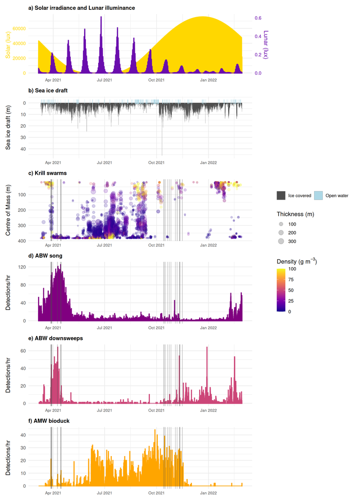

```r
# --- A: Solar and lunar irradiance --------------------------------------------
# Scale lunar lux to solar axis for dual-axis display
solar_max    <- max(dat$solar_lux, na.rm = TRUE)
lunar_max    <- max(dat$lunar_lux, na.rm = TRUE)
scale_factor <- solar_max / lunar_max

p1 <- ggplot(dat, aes(x = timeStamp)) +
  geom_col(aes(y = solar_lux),                  colour = "#FFD700", linewidth = 1) +
  geom_col(aes(y = lunar_lux * scale_factor),   colour = "#6A0DAD", linewidth = 1) +
  scale_y_continuous(
    name      = "Solar (lux)",
    sec.axis  = sec_axis(~ . / scale_factor, name = "Lunar (lux)")
  ) +
  theme_minimal(base_size = 12) +
  theme(
    axis.title.y.left  = element_text(color = "#FFD700"),
    axis.title.y.right = element_text(color = "#6A0DAD"),
    axis.text.y.right  = element_text(color = "#6A0DAD"),
    axis.text.y.left   = element_text(color = "#FFD700")
  ) +
  ggtitle("a) Solar irradiance and Lunar illuminance")

# --- B: Sea ice draft ---------------------------------------------------------
# Open-water hours overlaid as light blue rectangles
zero_ice       <- dat[dat$ice == 0, ]
dat$ice_status <- ifelse(dat$ice == 0, "Open water", "Ice covered")

p2 <- ggplot(dat, aes(x = timeStamp, y = ice, fill = ice_status)) +
  geom_col(colour = "grey30", linewidth = 0.1) +
  geom_rect(                              # open-water highlight
    data        = zero_ice,
    inherit.aes = FALSE,
    aes(xmin = timeStamp, xmax = timeStamp + 3600, ymin = -3, ymax = 1),
    fill  = "lightblue",
    alpha = 1
  ) +
  scale_fill_manual(
    values       = c("Open water" = "lightblue", "Ice covered" = "grey30"),
    na.translate = FALSE,
    name         = NULL
  ) +
  scale_y_reverse(name = "Sea ice draft (m)") +
  theme_minimal(base_size = 12) +
  theme(legend.position = "top",
        legend.title    = element_text(size = 10),
        legend.text     = element_text(size = 9)) +
  ggtitle("b) Sea ice draft")

# --- C: Krill swarm properties (depth, density, thickness) -------------------
p3 <- ggplot(dat, aes(x = timeStamp, y = Center_of_mass,
                      colour = rho_v, size = Thickness_mean)) +
  geom_point(alpha = 0.2) +
  geom_rect(                              # overlap period shading
    data        = overlap_ranges,
    inherit.aes = FALSE,
    aes(xmin = as.POSIXct(start - 1, origin = "2021-01-01", tz = "UTC"),
        xmax = as.POSIXct(end,       origin = "2021-01-01", tz = "UTC"),
        ymin = -Inf, ymax = Inf),
    fill  = "grey30",
    alpha = 0.3
  ) +
  scale_y_reverse(name = "Centre of Mass (m)") +
  scale_colour_viridis(
    option   = "plasma",
    na.value = "grey80",
    limits   = c(0, 100),
    oob      = scales::squish,
    name     = expression("Density (g m"^-3*")")
  ) +
  scale_size_continuous(range = c(1, 5), name = "Thickness (m)") +
  theme_minimal(base_size = 12) +
  ggtitle("c) Krill swarms")

# Helper to build whale call panels (D, E, F) with consistent formatting
make_call_panel <- function(data, y_var, colour, title, overlap_ranges) {
  ggplot(data, aes(x = timeStamp, y = .data[[y_var]])) +
    geom_col(colour = colour, linewidth = 1) +
    geom_rect(
      data        = overlap_ranges,
      inherit.aes = FALSE,
      aes(xmin = as.POSIXct(start - 1, origin = "2021-01-01", tz = "UTC"),
          xmax = as.POSIXct(end,       origin = "2021-01-01", tz = "UTC"),
          ymin = -Inf, ymax = Inf),
      fill  = "grey30",
      alpha = 0.3
    ) +
    theme_minimal(base_size = 12) +
    labs(y = "Detections/hr", title = title)
}

p4 <- make_call_panel(dat, "Bm_Ant_ABZ", "#800080", "d) ABW song",       overlap_ranges)
p5 <- make_call_panel(dat, "Bm_D",       "#CC4678", "e) ABW downsweeps", overlap_ranges)
p6 <- make_call_panel(dat, "BD",         "#FFA500", "f) AMW bioduck",    overlap_ranges)

# --- Combine panels -----------------------------------------------------------
combined_plot <- (p1 / p2 / p3 / p4 / p5 / p6) +
  plot_layout(guides = "collect") &
  theme(
    axis.title.x = element_blank(),
    axis.text.x  = element_text(size = 8),
    plot.title   = element_text(size = 11, face = "bold")
  )
combined_plot
```

## 8. Whale call GAMs

Fit GAMs to hourly call detection rates for ABW song (m1), ABW downsweeps (m2), and AMW bioduck (m3). Covariates: hour of day, day of year (both cyclic splines), solar irradiance, lunar irradiance, and sea ice draft. Gaussian with log link used for count-like rate data.

```r
# --- m1: ABW song (Bm_Ant_ABZ) -----------------------------------------------
m1 <- gam(
  Bm_Ant_ABZ ~
    s(hour,        k = 15, bs = "cc") +   # cyclic: hour of day
    s(day_of_year, k = 15, bs = "cc") +   # cyclic: day of year
    s(solar_lux,   k = 6,  bs = "cr") +
    s(lunar_lux,   k = 6,  bs = "cr") +
    s(ice,         k = 6,  bs = "cr"),
  data   = dat,
  method = "ML",
  family = gaussian(link = "log"),
  gamma  = 1.4,                           # penalise complexity
  select = FALSE,
  knots  = list(hour = c(0, 24), day_of_year = c(0, 365))
)
summary(m1)
```

```
##
## Family: gaussian
## Link function: log
##
## Formula:
## Bm_Ant_ABZ ~ s(hour, k = 15, bs = "cc") + s(day_of_year, k = 15,
##     bs = "cc") + s(solar_lux, k = 6, bs = "cr") + s(lunar_lux,
##     k = 6, bs = "cr") + s(ice, k = 6, bs = "cr")
##
## Parametric coefficients:
##             Estimate Std. Error t value Pr(>|t|)
## (Intercept)  -0.4048     0.2604  -1.555     0.12
##
## Approximate significance of smooth terms:
##                   edf Ref.df       F  p-value
## s(hour)         9.172 13.000   44.14  < 2e-16 ***
## s(day_of_year) 12.096 13.000 1263.38  < 2e-16 ***
## s(solar_lux)    1.001  1.003   14.00 0.000182 ***
## s(lunar_lux)    3.717  3.949   50.98  < 2e-16 ***
## s(ice)          1.000  1.000   60.63  < 2e-16 ***
## ---
## Signif. codes:  0 '***' 0.001 '**' 0.01 '*' 0.05 '.' 0.1 ' ' 1
##
## R-sq.(adj) =  0.887   Deviance explained = 88.8%
## -ML =  20256  Scale est. = 43.415    n = 8551
```

```r
# --- m2: ABW downsweeps (Bm_D) -----------------------------------------------
m2 <- gam(
  Bm_D ~
    s(hour,        k = 15, bs = "cc") +
    s(day_of_year, k = 15, bs = "cc") +
    s(solar_lux,   k = 6,  bs = "cr") +
    s(lunar_lux,   k = 6,  bs = "cr") +
    s(ice,         k = 6,  bs = "cr"),
  data   = dat,
  method = "ML",
  family = gaussian(link = "log"),
  gamma  = 1.4,
  select = TRUE,                          # automatic term selection
  knots  = list(hour = c(0, 24), day_of_year = c(0, 365))
)
summary(m2)
```

```
##
## Family: gaussian
## Link function: log
##
## Formula:
## Bm_D ~ s(hour, k = 15, bs = "cc") + s(day_of_year, k = 15, bs = "cc") +
##     s(solar_lux, k = 6, bs = "cr") + s(lunar_lux, k = 6, bs = "cr") +
##     s(ice, k = 6, bs = "cr")
##
## Parametric coefficients:
##             Estimate Std. Error t value Pr(>|t|)
## (Intercept)  -37.504      9.591   -3.91 9.28e-05 ***
## ---
## Signif. codes:  0 '***' 0.001 '**' 0.01 '*' 0.05 '.' 0.1 ' ' 1
##
## Approximate significance of smooth terms:
##                    edf Ref.df       F p-value
## s(hour)        11.1518     13  15.001  <2e-16 ***
## s(day_of_year)  7.9115     10 213.420  <2e-16 ***
## s(solar_lux)    2.6356      5   8.402  <2e-16 ***
## s(lunar_lux)    2.1789      5  31.741  <2e-16 ***
## s(ice)          0.7804      5   0.739  0.0255 *
## ---
## Signif. codes:  0 '***' 0.001 '**' 0.01 '*' 0.05 '.' 0.1 ' ' 1
##
## R-sq.(adj) =   0.38   Deviance explained = 38.2%
## -ML =  16560  Scale est. = 12.923    n = 8551
```

```r
# --- m3: AMW bioduck (BD) -----------------------------------------------------
m3 <- gam(
  BD ~
    s(hour,        k = 15, bs = "cc") +
    s(day_of_year, k = 15, bs = "cc") +
    s(solar_lux,   k = 6,  bs = "cr") +
    s(lunar_lux,   k = 6,  bs = "cr") +
    s(ice,         k = 6,  bs = "cr"),
  data   = dat,
  method = "ML",
  family = gaussian(link = "log"),
  gamma  = 1.4,
  select = TRUE,
  knots  = list(hour = c(0, 24), day_of_year = c(0, 365))
)
summary(m3)
```

```
##
## Family: gaussian
## Link function: log
##
## Formula:
## BD ~ s(hour, k = 15, bs = "cc") + s(day_of_year, k = 15, bs = "cc") +
##     s(solar_lux, k = 6, bs = "cr") + s(lunar_lux, k = 6, bs = "cr") +
##     s(ice, k = 6, bs = "cr")
##
## Parametric coefficients:
##             Estimate Std. Error t value Pr(>|t|)
## (Intercept)  -1.6328     0.6675  -2.446   0.0145 *
## ---
## Signif. codes:  0 '***' 0.001 '**' 0.01 '*' 0.05 '.' 0.1 ' ' 1
##
## Approximate significance of smooth terms:
##                   edf Ref.df      F p-value
## s(hour)        7.4428     13 22.051  <2e-16 ***
## s(day_of_year) 7.9260     13 63.511  <2e-16 ***
## s(solar_lux)   3.8829      5 49.543  <2e-16 ***
## s(lunar_lux)   1.0960      5  7.567  <2e-16 ***
## s(ice)         0.6226      5  0.427  0.0599 .
## ---
## Signif. codes:  0 '***' 0.001 '**' 0.01 '*' 0.05 '.' 0.1 ' ' 1
##
## R-sq.(adj) =  0.316   Deviance explained = 31.8%
## -ML =  17419  Scale est. = 17.281    n = 8551
```

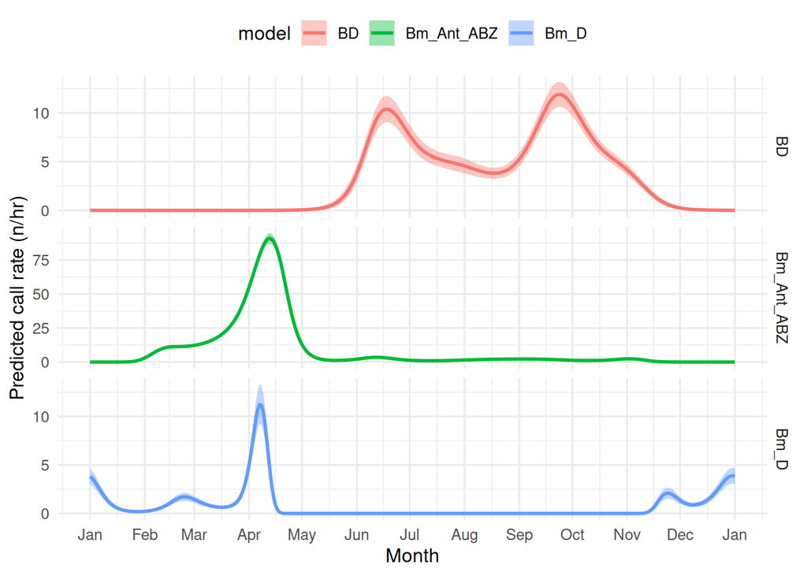

```r
# --- Predictions at mean covariate values across day of year -----------------
preds <- data.frame(
  hour        = mean(dat$hour),
  day_of_year = 0:365,
  solar_lux   = mean(dat$solar_lux, na.rm = TRUE),
  lunar_lux   = mean(dat$lunar_lux, na.rm = TRUE),
  ice         = mean(dat$ice,       na.rm = TRUE),
  BD = mean(dat$BD,na.rm=T),
  Bm_D=mean(dat$Bm_D,na.rm=T)
)

preds_m1 <- as.data.frame(predict(m1, newdata = preds, type = "response", se.fit = TRUE))
preds_m1$model <- "Bm_Ant_ABZ"

preds_m2 <- as.data.frame(predict(m2, newdata = preds, type = "response", se.fit = TRUE))
preds_m2$model <- "Bm_D"

preds_m3 <- as.data.frame(predict(m3, newdata = preds, type = "response", se.fit = TRUE))
preds_m3$model <- "BD"

preds_all <- rbind(preds_m1, preds_m2, preds_m3)
preds_all$day_of_year <- preds$day_of_year
preds_all$lower       <- preds_all$fit - 2 * preds_all$se.fit  # approx 95% CI
preds_all$upper       <- preds_all$fit + 2 * preds_all$se.fit

# Quick plot of whale call model predictions
ggplot(data = preds_all,
       aes(x = as.Date(day_of_year, origin = "2021-01-01"),
           y = fit, colour = model, group = model)) +
  geom_line(linewidth = 1) +
  geom_ribbon(aes(ymin = lower, ymax = upper, fill = model),
              alpha = 0.4, colour = NA) +
  facet_grid(model ~ ., scales = "free_y") +
  scale_x_date(date_breaks = "1 month", date_labels = "%b") +
  theme_minimal(base_size = 12) +
  labs(y = "Predicted call rate (n/hr)", x = "Month") +
  theme(legend.position = "top")
```

## 9. Krill swarm GAMs

```r
# --- Krill density ------------------------------------------------------------
mdensity <- gam(
  rho_min ~
    s(hour,        k = 15, bs = "cc") +
    s(day_of_year, k = 15, bs = "cc") +
    s(solar_lux,   k = 6,  bs = "cr") +
    s(lunar_lux,   k = 6,  bs = "cr") +
    s(ice,         k = 6,  bs = "cr"),
  data   = dat,
  method = "ML",
  family = Gamma(link = "log"),
  gamma  = 1.4,
  select = TRUE,
  knots  = list(hour = c(0, 24), day_of_year = c(0, 365))
)
summary(mdensity)
```

```
##
## Family: Gamma
## Link function: log
##
## Formula:
## rho_min ~ s(hour, k = 15, bs = "cc") + s(day_of_year, k = 15,
##     bs = "cc") + s(solar_lux, k = 6, bs = "cr") + s(lunar_lux,
##     k = 6, bs = "cr") + s(ice, k = 6, bs = "cr")
##
## Parametric coefficients:
##             Estimate Std. Error t value Pr(>|t|)
## (Intercept)   3.4452     0.0332   103.8   <2e-16 ***
## ---
## Signif. codes:  0 '***' 0.001 '**' 0.01 '*' 0.05 '.' 0.1 ' ' 1
##
## Approximate significance of smooth terms:
##                    edf Ref.df      F p-value
## s(hour)         8.8262     13 35.077  <2e-16 ***
## s(day_of_year) 12.1576     13 31.387  <2e-16 ***
## s(solar_lux)    3.1277      5 27.735  <2e-16 ***
## s(lunar_lux)    2.7060      5  7.758  <2e-16 ***
## s(ice)          0.7559      5  0.356   0.124
## ---
## Signif. codes:  0 '***' 0.001 '**' 0.01 '*' 0.05 '.' 0.1 ' ' 1
##
## R-sq.(adj) =  0.124   Deviance explained = 41.9%
## -ML =   8757  Scale est. = 3.026     n = 2745
```

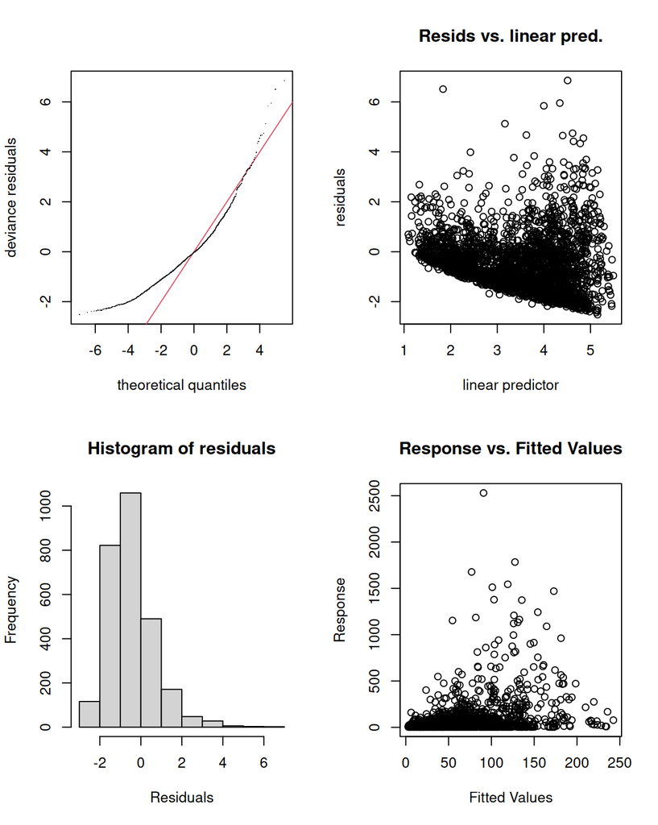

```
##
## Method: ML   Optimizer: outer newton
## full convergence after 10 iterations.
## Gradient range [-0.002242973,0.001177097]
## (score 8756.968 & scale 3.026036).
## Hessian positive definite, eigenvalue range [0.0001126849,1316.831].
## Model rank =  42 / 42
##
## Basis dimension (k) checking results. Low p-value (k-index<1) may
## indicate that k is too low, especially if edf is close to k'.
##
##                    k'    edf k-index p-value
## s(hour)        13.000  8.826    0.71  <2e-16 ***
## s(day_of_year) 13.000 12.158    0.32  <2e-16 ***
## s(solar_lux)    5.000  3.128    0.63  <2e-16 ***
## s(lunar_lux)    5.000  2.706    0.57  <2e-16 ***
## s(ice)          5.000  0.756    0.79  <2e-16 ***
## ---
## Signif. codes:  0 '***' 0.001 '**' 0.01 '*' 0.05 '.' 0.1 ' ' 1
```

```r
gam.check(mdensity)
```

```r
concurvity(mdensity)
```

```
##                  para    s(hour) s(day_of_year) s(solar_lux) s(lunar_lux)
## worst    1.075035e-28 0.55934688      0.6822938    0.7449439   0.19813319
## observed 1.075035e-28 0.54422434      0.6032352    0.6854265   0.07503223
## estimate 1.075035e-28 0.07994713      0.1506007    0.2202778   0.13725258
##             s(ice)
## worst    0.1531636
## observed 0.1294425
## estimate 0.0920225
```

```r
mdensity_BD<-update(mdensity, .~. + s(BD,k=6,bs='cr'))
concurvity(mdensity_BD)
```

```
##                  para    s(hour) s(day_of_year) s(solar_lux) s(lunar_lux)
## worst    1.481507e-28 0.57629107      0.7071643    0.7488859    0.2065158
## observed 1.481507e-28 0.55685452      0.5994359    0.6876462    0.0843916
## estimate 1.481507e-28 0.08480036      0.1714302    0.2213074    0.1465915
##              s(ice)     s(BD)
## worst    0.15651740 0.3343285
## observed 0.13194909 0.2596243
## estimate 0.09440962 0.1576736
```

```r
summary(mdensity_BD)
```

```
##
## Family: Gamma
## Link function: log
##
## Formula:
## rho_min ~ s(hour, k = 15, bs = "cc") + s(day_of_year, k = 15,
##     bs = "cc") + s(solar_lux, k = 6, bs = "cr") + s(lunar_lux,
##     k = 6, bs = "cr") + s(ice, k = 6, bs = "cr") + s(BD, k = 6,
##     bs = "cr")
##
## Parametric coefficients:
##             Estimate Std. Error t value Pr(>|t|)
## (Intercept)  3.44102    0.03283   104.8   <2e-16 ***
## ---
## Signif. codes:  0 '***' 0.001 '**' 0.01 '*' 0.05 '.' 0.1 ' ' 1
##
## Approximate significance of smooth terms:
##                    edf Ref.df      F p-value
## s(hour)         8.8308     13 32.561 < 2e-16 ***
## s(day_of_year) 12.1573     13 30.135 < 2e-16 ***
## s(solar_lux)    3.0947      5 25.672 < 2e-16 ***
## s(lunar_lux)    2.7455      5  8.712 < 2e-16 ***
## s(ice)          0.7855      5  0.424 0.09960 .
## s(BD)           0.9716      5  1.560 0.00382 **
## ---
## Signif. codes:  0 '***' 0.001 '**' 0.01 '*' 0.05 '.' 0.1 ' ' 1
##
## R-sq.(adj) =  0.126   Deviance explained = 42.2%
## -ML = 8752.3  Scale est. = 2.9593    n = 2745
```

```r
mdensity_BD_Bm_D<-update(mdensity_BD, .~. + s(Bm_D,k=6,bs='cr'))
concurvity(mdensity_BD_Bm_D)
```

```
##                  para    s(hour) s(day_of_year) s(solar_lux) s(lunar_lux)
## worst    1.548271e-28 0.57663780      0.7198378    0.7496345   0.20951348
## observed 1.548271e-28 0.55774251      0.6054057    0.6873734   0.08991125
## estimate 1.548271e-28 0.08622678      0.1899893    0.2234384   0.15100139
##              s(ice)     s(BD)   s(Bm_D)
## worst    0.15978514 0.3355294 0.3765980
## observed 0.13754167 0.2590722 0.2590819
## estimate 0.09889885 0.1582027 0.1685907
```

```r
summary(mdensity_BD_Bm_D)
```

```
##
## Family: Gamma
## Link function: log
##
## Formula:
## rho_min ~ s(hour, k = 15, bs = "cc") + s(day_of_year, k = 15,
##     bs = "cc") + s(solar_lux, k = 6, bs = "cr") + s(lunar_lux,
##     k = 6, bs = "cr") + s(ice, k = 6, bs = "cr") + s(BD, k = 6,
##     bs = "cr") + s(Bm_D, k = 6, bs = "cr")
##
## Parametric coefficients:
##             Estimate Std. Error t value Pr(>|t|)
## (Intercept)  3.44017    0.03281   104.9   <2e-16 ***
## ---
## Signif. codes:  0 '***' 0.001 '**' 0.01 '*' 0.05 '.' 0.1 ' ' 1
##
## Approximate significance of smooth terms:
##                    edf Ref.df      F p-value
## s(hour)         8.8135     13 32.612 < 2e-16 ***
## s(day_of_year) 12.1486     13 30.187 < 2e-16 ***
## s(solar_lux)    3.0814      5 25.838 < 2e-16 ***
## s(lunar_lux)    2.7428      5  8.530 < 2e-16 ***
## s(ice)          0.7859      5  0.425 0.09913 .
## s(BD)           0.9285      5  1.516 0.00421 **
## s(Bm_D)         0.8616      5  0.264 0.19893
## ---
## Signif. codes:  0 '***' 0.001 '**' 0.01 '*' 0.05 '.' 0.1 ' ' 1
##
## R-sq.(adj) =  0.127   Deviance explained = 42.3%
## -ML = 8751.9  Scale est. = 2.9549    n = 2745
```

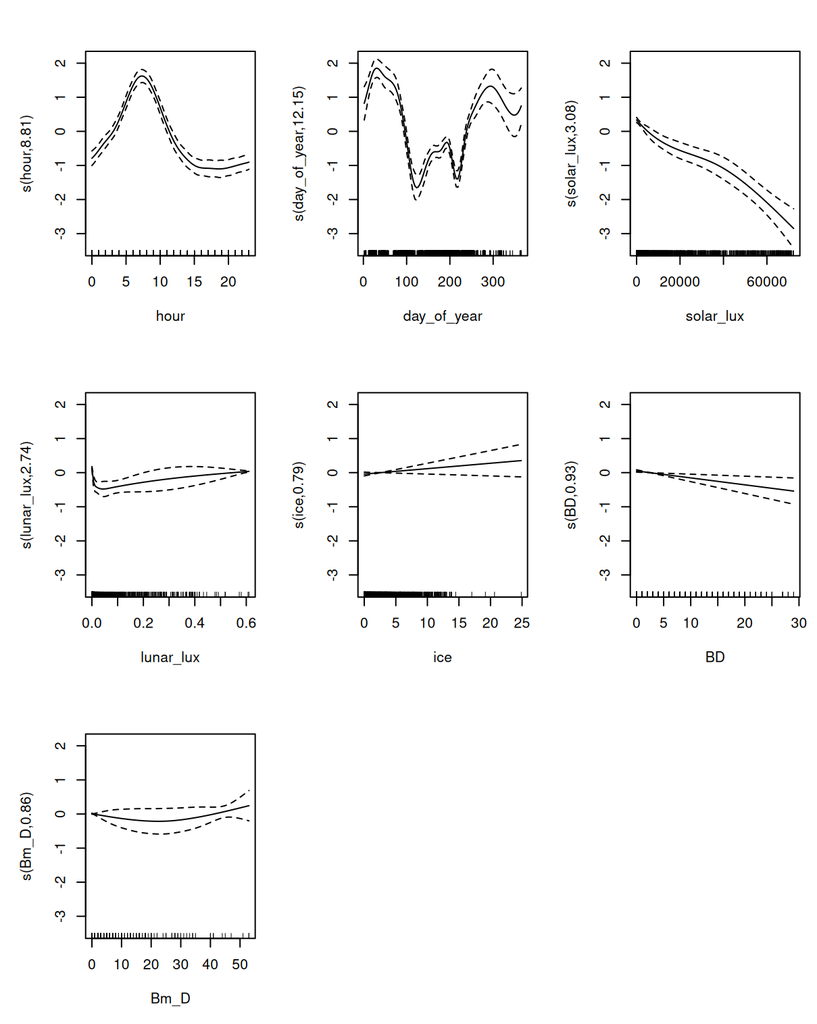

```r
plot(mdensity_BD_Bm_D,pages=1)
```

```r
mdensity_BD_Bm_D_Bm_Ant_ABZ<-update(mdensity_BD_Bm_D, .~. + s(Bm_Ant_ABZ,k=6,bs='cr')) #I'd probably not put Bm_Ant_ABZ
concurvity(mdensity_BD_Bm_D_Bm_Ant_ABZ)
```

```
##                  para    s(hour) s(day_of_year) s(solar_lux) s(lunar_lux)
## worst    1.632508e-28 0.57692417      0.9209393    0.7501744    0.2154812
## observed 1.632508e-28 0.55799542      0.6167328    0.6875934    0.0952617
## estimate 1.632508e-28 0.08808938      0.2549154    0.2251057    0.1522671
##             s(ice)     s(BD)   s(Bm_D) s(Bm_Ant_ABZ)
## worst    0.1752441 0.3384780 0.3983854     0.9220171
## observed 0.1666173 0.2603259 0.2864454     0.5373179
## estimate 0.1177588 0.1602511 0.1862995     0.3818510
```

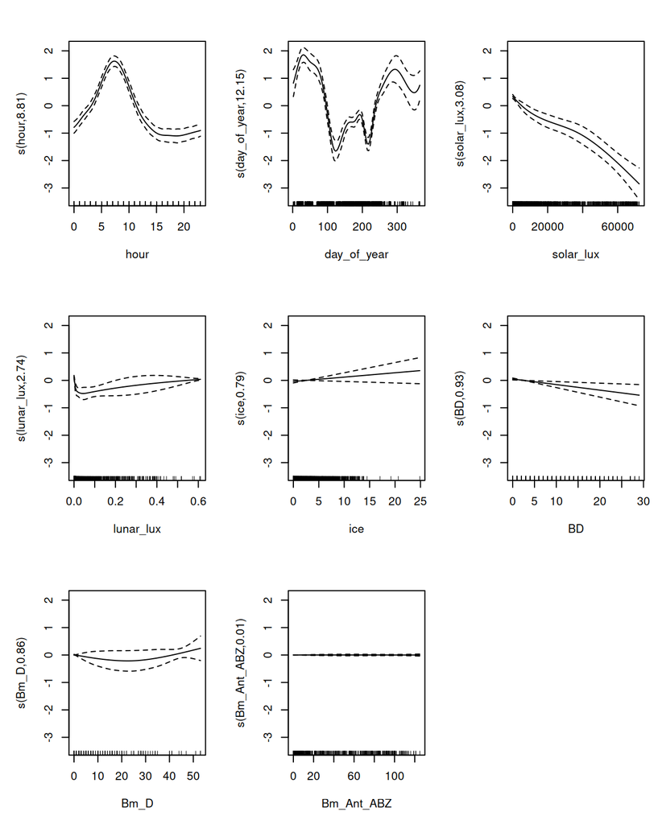

```r
plot(mdensity_BD_Bm_D_Bm_Ant_ABZ,pages=1)
```

```r
#over write the mdensity model object with mdensity_BD_Bm_D
mdensitySTORE <- mdensity
mdensity <- mdensity_BD_Bm_D
# --- Centre of mass depth -------------------Bm_D_rate# --- Centre of mass depth -----------------------------------------------------
mcom <- gam(
  Center_of_mass ~
    s(hour,        k = 15, bs = "cc") +
    s(day_of_year, k = 15, bs = "cc") +
    s(solar_lux,   k = 6,  bs = "cr") +
    s(lunar_lux,   k = 6,  bs = "cr") +
    s(ice,         k = 6,  bs = "cr"),
  data   = dat,
  method = "ML",
  family = Gamma(link = "log"),
  gamma  = 1.4,
  select = TRUE,
  knots  = list(hour = c(0, 24), day_of_year = c(0, 365))
)
summary(mcom)
```

```
##
## Family: Gamma
## Link function: log
##
## Formula:
## Center_of_mass ~ s(hour, k = 15, bs = "cc") + s(day_of_year,
##     k = 15, bs = "cc") + s(solar_lux, k = 6, bs = "cr") + s(lunar_lux,
##     k = 6, bs = "cr") + s(ice, k = 6, bs = "cr")
##
## Parametric coefficients:
##             Estimate Std. Error t value Pr(>|t|)
## (Intercept) 5.434062   0.008856   613.6   <2e-16 ***
## ---
## Signif. codes:  0 '***' 0.001 '**' 0.01 '*' 0.05 '.' 0.1 ' ' 1
##
## Approximate significance of smooth terms:
##                      edf Ref.df       F p-value
## s(hour)         4.316539     13   9.248  <2e-16 ***
## s(day_of_year) 12.788097     13 406.222  <2e-16 ***
## s(solar_lux)    0.004258      5   0.001   0.398
## s(lunar_lux)    0.003226      5   0.000   0.737
## s(ice)          3.525087      5  24.235  <2e-16 ***
## ---
## Signif. codes:  0 '***' 0.001 '**' 0.01 '*' 0.05 '.' 0.1 ' ' 1
##
## R-sq.(adj) =  0.538   Deviance explained = 49.1%
## -ML =  12096  Scale est. = 0.2153    n = 2745
```

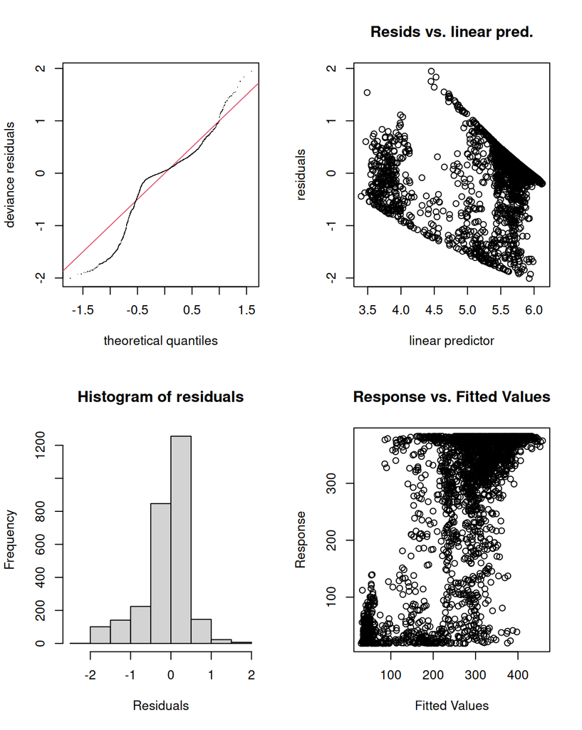

```
##
## Method: ML   Optimizer: outer newton
## full convergence after 12 iterations.
## Gradient range [-0.0009440864,3.068817e-05]
## (score 12095.51 & scale 0.2153016).
## Hessian positive definite, eigenvalue range [0.0004685655,1076.343].
## Model rank =  42 / 42
##
## Basis dimension (k) checking results. Low p-value (k-index<1) may
## indicate that k is too low, especially if edf is close to k'.
##
##                      k'      edf k-index p-value
## s(hour)        13.00000  4.31654    0.74  <2e-16 ***
## s(day_of_year) 13.00000 12.78810    0.26  <2e-16 ***
## s(solar_lux)    5.00000  0.00426    0.73  <2e-16 ***
## s(lunar_lux)    5.00000  0.00323    0.55  <2e-16 ***
## s(ice)          5.00000  3.52509    0.83  <2e-16 ***
## ---
## Signif. codes:  0 '***' 0.001 '**' 0.01 '*' 0.05 '.' 0.1 ' ' 1
```

```r
gam.check(mcom)
```

```r
concurvity(mcom)
```

```
##                  para    s(hour) s(day_of_year) s(solar_lux) s(lunar_lux)
## worst    1.075035e-28 0.55934688      0.6822938    0.7449439    0.1981332
## observed 1.075035e-28 0.50407428      0.5473498    0.6703755    0.1789228
## estimate 1.075035e-28 0.07994713      0.1506007    0.2202778    0.1372526
##             s(ice)
## worst    0.1531636
## observed 0.1092580
## estimate 0.0920225
```

```r
mcom_BD<-update(mcom, .~. + s(BD,k=6,bs='cr'))
concurvity(mcom_BD)
```

```
##                  para    s(hour) s(day_of_year) s(solar_lux) s(lunar_lux)
## worst    1.481507e-28 0.57629107      0.7071643    0.7488859    0.2065158
## observed 1.481507e-28 0.52797053      0.5658563    0.6759334    0.1911326
## estimate 1.481507e-28 0.08480036      0.1714302    0.2213074    0.1465915
##              s(ice)     s(BD)
## worst    0.15651740 0.3343285
## observed 0.11160019 0.2763661
## estimate 0.09440962 0.1576736
```

```r
summary(mcom_BD)
```

```
##
## Family: Gamma
## Link function: log
##
## Formula:
## Center_of_mass ~ s(hour, k = 15, bs = "cc") + s(day_of_year,
##     k = 15, bs = "cc") + s(solar_lux, k = 6, bs = "cr") + s(lunar_lux,
##     k = 6, bs = "cr") + s(ice, k = 6, bs = "cr") + s(BD, k = 6,
##     bs = "cr")
##
## Parametric coefficients:
##             Estimate Std. Error t value Pr(>|t|)
## (Intercept)  5.43387    0.00886   613.3   <2e-16 ***
## ---
## Signif. codes:  0 '***' 0.001 '**' 0.01 '*' 0.05 '.' 0.1 ' ' 1
##
## Approximate significance of smooth terms:
##                      edf Ref.df       F p-value
## s(hour)         4.358309     13   9.537  <2e-16 ***
## s(day_of_year) 12.787699     13 391.888  <2e-16 ***
## s(solar_lux)    0.003809      5   0.001  0.2727
## s(lunar_lux)    0.001303      5   0.000  0.6011
## s(ice)          3.522352      5  24.604  <2e-16 ***
## s(BD)           0.701408      5   0.645  0.0226 *
## ---
## Signif. codes:  0 '***' 0.001 '**' 0.01 '*' 0.05 '.' 0.1 ' ' 1
##
## R-sq.(adj) =  0.538   Deviance explained = 49.2%
## -ML =  12095  Scale est. = 0.21548   n = 2745
```

```r
mcom_BD_Bm_D<-update(mcom_BD, .~. + s(Bm_D,k=6,bs='cr'))
concurvity(mcom_BD_Bm_D)
```

```
##                  para    s(hour) s(day_of_year) s(solar_lux) s(lunar_lux)
## worst    1.548271e-28 0.57663780      0.7198378    0.7496345    0.2095135
## observed 1.548271e-28 0.53346821      0.5823103    0.6706850    0.1910247
## estimate 1.548271e-28 0.08622678      0.1899893    0.2234384    0.1510014
##              s(ice)     s(BD)   s(Bm_D)
## worst    0.15978514 0.3355294 0.3765980
## observed 0.11692965 0.2833073 0.3638536
## estimate 0.09889885 0.1582027 0.1685907
```

```r
summary(mcom_BD_Bm_D)
```

```
##
## Family: Gamma
## Link function: log
##
## Formula:
## Center_of_mass ~ s(hour, k = 15, bs = "cc") + s(day_of_year,
##     k = 15, bs = "cc") + s(solar_lux, k = 6, bs = "cr") + s(lunar_lux,
##     k = 6, bs = "cr") + s(ice, k = 6, bs = "cr") + s(BD, k = 6,
##     bs = "cr") + s(Bm_D, k = 6, bs = "cr")
##
## Parametric coefficients:
##             Estimate Std. Error t value Pr(>|t|)
## (Intercept) 5.432533   0.008873   612.2   <2e-16 ***
## ---
## Signif. codes:  0 '***' 0.001 '**' 0.01 '*' 0.05 '.' 0.1 ' ' 1
##
## Approximate significance of smooth terms:
##                      edf Ref.df       F p-value
## s(hour)         4.339343     13   9.945  <2e-16 ***
## s(day_of_year) 12.756382     13 393.115  <2e-16 ***
## s(solar_lux)    0.002264      5   0.000  0.4383
## s(lunar_lux)    0.001563      5   0.000  0.8427
## s(ice)          3.545444      5  23.962  <2e-16 ***
## s(BD)           0.716076      5   0.624  0.0239 *
## s(Bm_D)         2.664423      5   6.318  <2e-16 ***
## ---
## Signif. codes:  0 '***' 0.001 '**' 0.01 '*' 0.05 '.' 0.1 ' ' 1
##
## R-sq.(adj) =  0.537   Deviance explained = 49.6%
## -ML =  12090  Scale est. = 0.21613   n = 2745
```

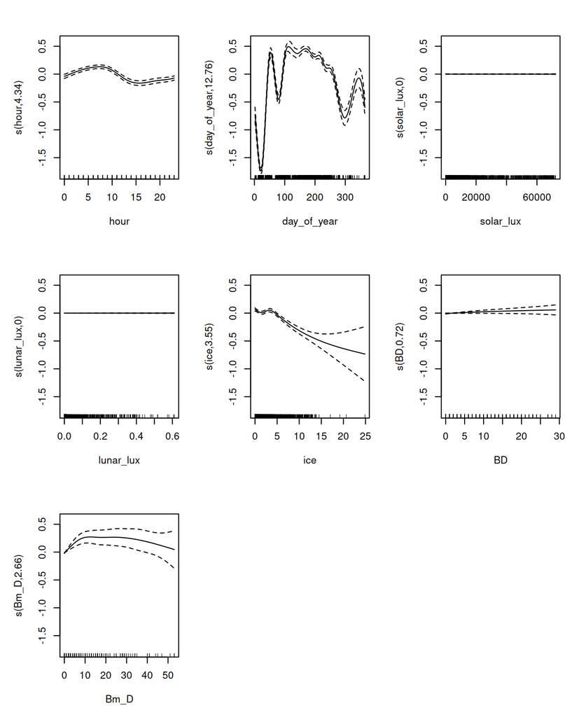

```r
plot(mcom_BD_Bm_D,pages=1)
```

```r
mcom_BD_Bm_D_Bm_Ant_ABZ<-update(mcom_BD_Bm_D, .~. + s(Bm_Ant_ABZ,k=6,bs='cr')) #I'd probably not put Bm_Ant_ABZ
concurvity(mcom_BD_Bm_D_Bm_Ant_ABZ)
```

```
##                  para    s(hour) s(day_of_year) s(solar_lux) s(lunar_lux)
## worst    1.632508e-28 0.57692417      0.9209393    0.7501744    0.2154812
## observed 1.632508e-28 0.52776693      0.6038404    0.6914269    0.1893093
## estimate 1.632508e-28 0.08808938      0.2549154    0.2251057    0.1522671
##             s(ice)     s(BD)   s(Bm_D) s(Bm_Ant_ABZ)
## worst    0.1752441 0.3384780 0.3983854     0.9220171
## observed 0.1426848 0.2626132 0.3756474     0.9182504
## estimate 0.1177588 0.1602511 0.1862995     0.3818510
```

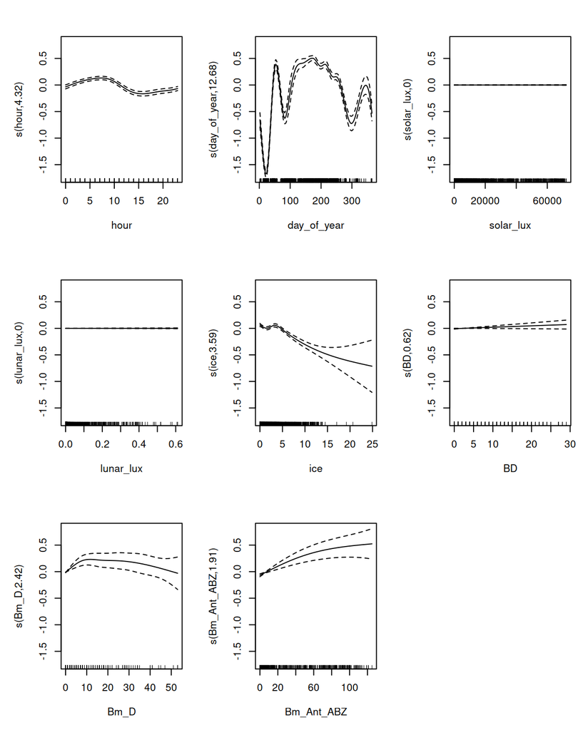

```r
plot(mcom_BD_Bm_D_Bm_Ant_ABZ,pages=1)
```

```r
#over write the mdensity model object with mdensity_BD_Bm_D
mcomSTORE <- mcom
mcom <- mcom_BD_Bm_D


# --- Mean swarm thickness -----------------------------------------------------
mthickness <- gam(
  Thickness_mean ~
    s(hour,        k = 15, bs = "cc") +
    s(day_of_year, k = 15, bs = "cc") +
    s(solar_lux,   k = 6,  bs = "cr") +
    s(lunar_lux,   k = 6,  bs = "cr") +
    s(ice,         k = 6,  bs = "cr"),
  data   = dat,
  method = "ML",
  family = Gamma(link = "log"),
  gamma  = 1.4,
  select = TRUE,
  knots  = list(hour = c(0, 24), day_of_year = c(0, 365))
)
summary(mthickness)
```

```
##
## Family: Gamma
## Link function: log
##
## Formula:
## Thickness_mean ~ s(hour, k = 15, bs = "cc") + s(day_of_year,
##     k = 15, bs = "cc") + s(solar_lux, k = 6, bs = "cr") + s(lunar_lux,
##     k = 6, bs = "cr") + s(ice, k = 6, bs = "cr")
##
## Parametric coefficients:
##             Estimate Std. Error t value Pr(>|t|)
## (Intercept)  3.36070    0.01597   210.4   <2e-16 ***
## ---
## Signif. codes:  0 '***' 0.001 '**' 0.01 '*' 0.05 '.' 0.1 ' ' 1
##
## Approximate significance of smooth terms:
##                      edf Ref.df      F p-value
## s(hour)         7.972341     13  72.45  <2e-16 ***
## s(day_of_year) 12.215287     13 144.63  <2e-16 ***
## s(solar_lux)    0.995841      5  54.16  <2e-16 ***
## s(lunar_lux)    1.318560      5  13.61  <2e-16 ***
## s(ice)          0.000865      5   0.00   0.724
## ---
## Signif. codes:  0 '***' 0.001 '**' 0.01 '*' 0.05 '.' 0.1 ' ' 1
##
## R-sq.(adj) =  0.466   Deviance explained = 53.7%
## -ML = 8477.7  Scale est. = 0.70017   n = 2745
```

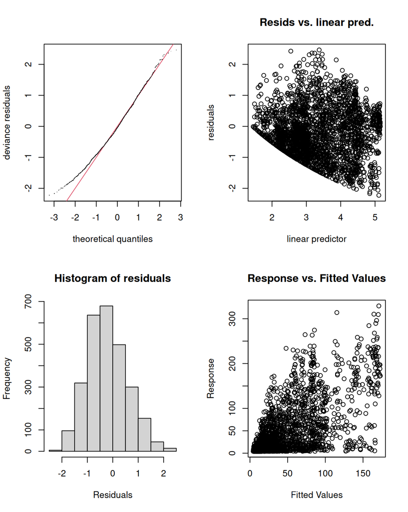

```
##
## Method: ML   Optimizer: outer newton
## full convergence after 17 iterations.
## Gradient range [-0.0002341269,8.51849e-05]
## (score 8477.713 & scale 0.7001698).
## Hessian positive definite, eigenvalue range [0.0001165025,1167.275].
## Model rank =  42 / 42
##
## Basis dimension (k) checking results. Low p-value (k-index<1) may
## indicate that k is too low, especially if edf is close to k'.
##
##                      k'      edf k-index p-value
## s(hour)        1.30e+01 7.97e+00    0.73  <2e-16 ***
## s(day_of_year) 1.30e+01 1.22e+01    0.29  <2e-16 ***
## s(solar_lux)   5.00e+00 9.96e-01    0.50  <2e-16 ***
## s(lunar_lux)   5.00e+00 1.32e+00    0.57  <2e-16 ***
## s(ice)         5.00e+00 8.65e-04    0.83  <2e-16 ***
## ---
## Signif. codes:  0 '***' 0.001 '**' 0.01 '*' 0.05 '.' 0.1 ' ' 1
```

```r
gam.check(mthickness)
```

```r
concurvity(mthickness)
```

```
##                  para    s(hour) s(day_of_year) s(solar_lux) s(lunar_lux)
## worst    1.075035e-28 0.55934688      0.6822938    0.7449439    0.1981332
## observed 1.075035e-28 0.55389930      0.4878457    0.6717699    0.1742998
## estimate 1.075035e-28 0.07994713      0.1506007    0.2202778    0.1372526
##             s(ice)
## worst    0.1531636
## observed 0.1400351
## estimate 0.0920225
```

```r
mthickness_BD<-update(mthickness, .~. + s(BD,k=6,bs='cr'))
concurvity(mthickness_BD)
```

```
##                  para    s(hour) s(day_of_year) s(solar_lux) s(lunar_lux)
## worst    1.481507e-28 0.57629107      0.7071643    0.7488859    0.2065158
## observed 1.481507e-28 0.56883556      0.5760559    0.6757371    0.1800265
## estimate 1.481507e-28 0.08480036      0.1714302    0.2213074    0.1465915
##              s(ice)     s(BD)
## worst    0.15651740 0.3343285
## observed 0.14451044 0.2482839
## estimate 0.09440962 0.1576736
```

```r
summary(mthickness_BD)
```

```
##
## Family: Gamma
## Link function: log
##
## Formula:
## Thickness_mean ~ s(hour, k = 15, bs = "cc") + s(day_of_year,
##     k = 15, bs = "cc") + s(solar_lux, k = 6, bs = "cr") + s(lunar_lux,
##     k = 6, bs = "cr") + s(ice, k = 6, bs = "cr") + s(BD, k = 6,
##     bs = "cr")
##
## Parametric coefficients:
##             Estimate Std. Error t value Pr(>|t|)
## (Intercept)  3.35933    0.01592     211   <2e-16 ***
## ---
## Signif. codes:  0 '***' 0.001 '**' 0.01 '*' 0.05 '.' 0.1 ' ' 1
##
## Approximate significance of smooth terms:
##                      edf Ref.df       F p-value
## s(hour)         7.986203     13  70.061 < 2e-16 ***
## s(day_of_year) 12.223543     13 120.640 < 2e-16 ***
## s(solar_lux)    0.995751      5  52.793 < 2e-16 ***
## s(lunar_lux)    1.054341      5  12.606 < 2e-16 ***
## s(ice)          0.001305      5   0.000 0.75641
## s(BD)           1.682901      5   1.846 0.00297 **
## ---
## Signif. codes:  0 '***' 0.001 '**' 0.01 '*' 0.05 '.' 0.1 ' ' 1
##
## R-sq.(adj) =  0.474   Deviance explained = 53.9%
## -ML = 8475.7  Scale est. = 0.69549   n = 2745
```

```r
mthickness_BD_Bm_D<-update(mthickness_BD, .~. + s(Bm_D,k=6,bs='cr'))
concurvity(mthickness_BD_Bm_D)
```

```
##                  para    s(hour) s(day_of_year) s(solar_lux) s(lunar_lux)
## worst    1.548271e-28 0.57663780      0.7198378    0.7496345    0.2095135
## observed 1.548271e-28 0.56873761      0.6090167    0.6760956    0.1875542
## estimate 1.548271e-28 0.08622678      0.1899893    0.2234384    0.1510014
##              s(ice)     s(BD)   s(Bm_D)
## worst    0.15978514 0.3355294 0.3765980
## observed 0.14794791 0.2448742 0.3423162
## estimate 0.09889885 0.1582027 0.1685907
```

```r
summary(mthickness_BD_Bm_D)
```

```
##
## Family: Gamma
## Link function: log
##
## Formula:
## Thickness_mean ~ s(hour, k = 15, bs = "cc") + s(day_of_year,
##     k = 15, bs = "cc") + s(solar_lux, k = 6, bs = "cr") + s(lunar_lux,
##     k = 6, bs = "cr") + s(ice, k = 6, bs = "cr") + s(BD, k = 6,
##     bs = "cr") + s(Bm_D, k = 6, bs = "cr")
##
## Parametric coefficients:
##             Estimate Std. Error t value Pr(>|t|)
## (Intercept)  3.35802    0.01586   211.8   <2e-16 ***
## ---
## Signif. codes:  0 '***' 0.001 '**' 0.01 '*' 0.05 '.' 0.1 ' ' 1
##
## Approximate significance of smooth terms:
##                      edf Ref.df       F p-value
## s(hour)         8.026125     13  70.192 < 2e-16 ***
## s(day_of_year) 12.223057     13 118.817 < 2e-16 ***
## s(solar_lux)    0.997296      5  53.511 < 2e-16 ***
## s(lunar_lux)    1.403724      5  13.408 < 2e-16 ***
## s(ice)          0.003453      5   0.000 0.64896
## s(BD)           1.707158      5   1.848 0.00307 **
## s(Bm_D)         1.542003      5   1.393 0.00621 **
## ---
## Signif. codes:  0 '***' 0.001 '**' 0.01 '*' 0.05 '.' 0.1 ' ' 1
##
## R-sq.(adj) =  0.476   Deviance explained = 54.1%
## -ML = 8474.1  Scale est. = 0.69016   n = 2745
```

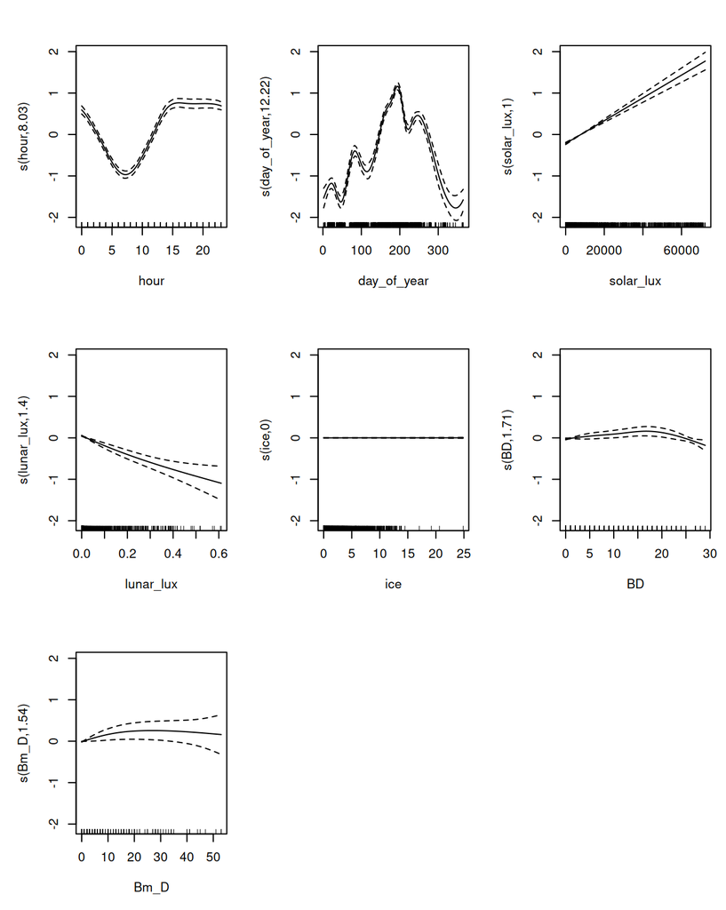

```r
plot(mthickness_BD_Bm_D,pages=1)
```

```r
mthickness_BD_Bm_D_Bm_Ant_ABZ<-update(mthickness_BD_Bm_D, .~. + s(Bm_Ant_ABZ,k=6,bs='cr')) #I'd probably not put Bm_Ant_ABZ
concurvity(mthickness_BD_Bm_D_Bm_Ant_ABZ)
```

```
##                  para    s(hour) s(day_of_year) s(solar_lux) s(lunar_lux)
## worst    1.632508e-28 0.57692417      0.9209393    0.7501744    0.2154812
## observed 1.632508e-28 0.56825900      0.6813546    0.6762564    0.1907785
## estimate 1.632508e-28 0.08808938      0.2549154    0.2251057    0.1522671
##             s(ice)     s(BD)   s(Bm_D) s(Bm_Ant_ABZ)
## worst    0.1752441 0.3384780 0.3983854     0.9220171
## observed 0.1739333 0.2440907 0.3098155     0.9124577
## estimate 0.1177588 0.1602511 0.1862995     0.3818510
```

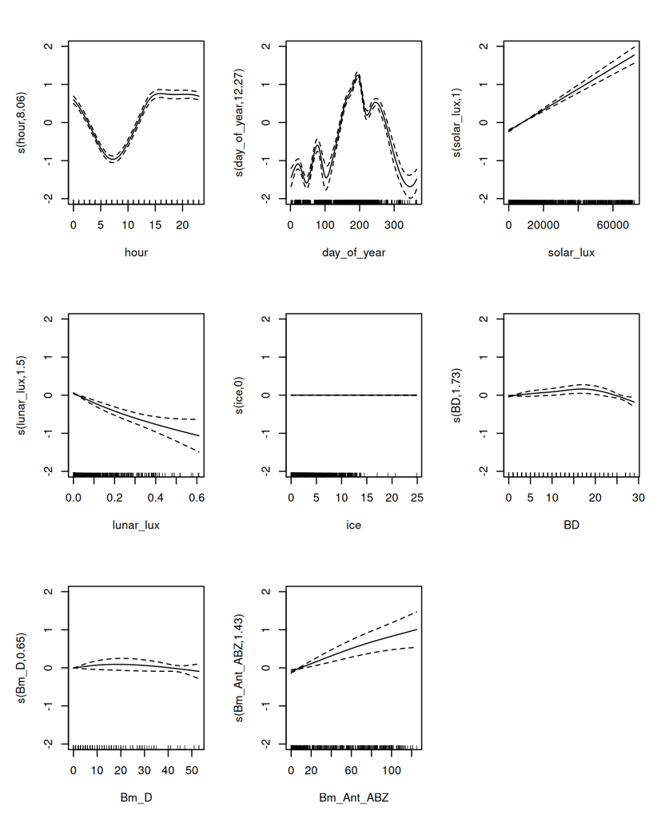

```r
plot(mthickness_BD_Bm_D_Bm_Ant_ABZ,pages=1)
```

```r
#over write the mdensity model object with mdensity_BD_Bm_D
mthicknessSTORE <- mthickness
mthickness <- mthickness_BD_Bm_D



# --- Combine all model predictions --------------------------------------------
preds_mdensity <- as.data.frame(
  predict(mdensity,   newdata = preds, type = "response", se.fit = TRUE))
preds_mdensity$model <- "krill_density"

preds_mcom <- as.data.frame(
  predict(mcom,       newdata = preds, type = "response", se.fit = TRUE))
preds_mcom$model <- "centre_of_mass"

preds_mthickness <- as.data.frame(
  predict(mthickness, newdata = preds, type = "response", se.fit = TRUE))
preds_mthickness$model <- "corrected_thickness"

# Combine whale and krill predictions into a single data frame
preds_all2 <- rbind(preds_m1, preds_m2, preds_m3,
                    preds_mdensity, preds_mthickness, preds_mcom)
preds_all2$day_of_year <- rep(0:365, 6)
preds_all2$lower       <- preds_all2$fit - 2 * preds_all2$se.fit
preds_all2$upper       <- preds_all2$fit + 2 * preds_all2$se.fit

# Order models for facet display (krill first, then whale calls)
preds_all2$model <- factor(
  preds_all2$model,
  levels = c("krill_density", "centre_of_mass", "corrected_thickness",
             "Bm_Ant_ABZ", "Bm_D", "BD")
)

# Facet strip labels
my_labels <- as_labeller(c(
  krill_density        = "Krill density\n(g/m^3)",
  centre_of_mass       = "Centre of mass\ndepth (m)",
  corrected_thickness  = "Thickness\n(m)",
  Bm_Ant_ABZ           = "ABW Song\n(Detections/h)",
  Bm_D                 = "Downsweep\n(Detections/h)",
  BD                   = "Bioduck\n(Detections/h)"
))
```

## 10. Figure 4a — GAM prediction time series (environmental colouring)

Seasonal predictions from all six GAMs with ±2 SE ribbons. Centre of mass y-axis is reversed (deeper = downward). Grey shading marks predator overlap periods. X-axis runs March–January to align with the austral year.

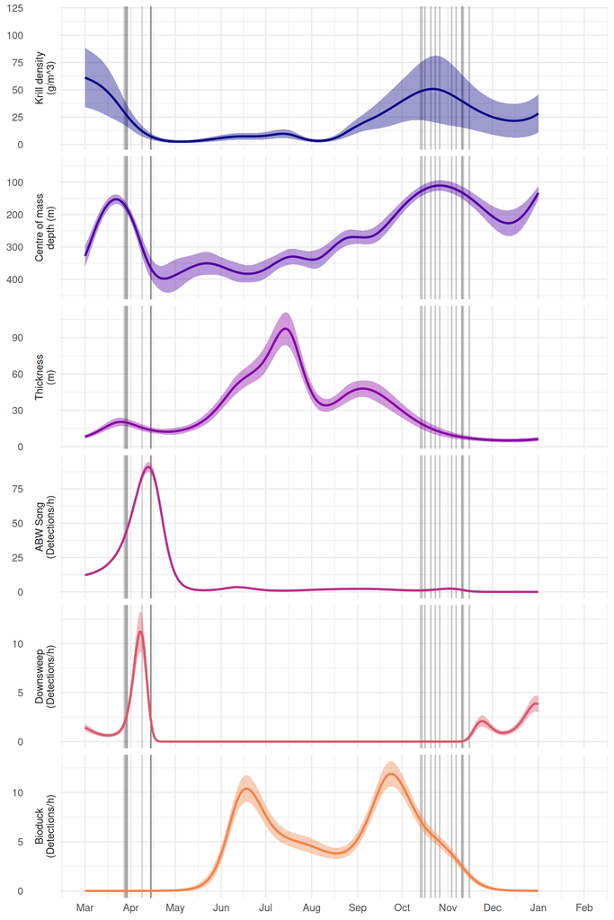

```r
ggplot(data = preds_all2,
       aes(x = as.Date(day_of_year, origin = "2021-01-01"),
           y = fit, colour = model, group = model)) +
  # Predator overlap shading (behind lines)
  geom_rect(
    data        = overlap_ranges,
    inherit.aes = FALSE,
    aes(xmin = as.Date(start - 1, origin = "2021-01-01"),
        xmax = as.Date(end,       origin = "2021-01-01"),
        ymin = -Inf, ymax = Inf),
    fill  = "grey30",
    alpha = 0.3
  ) +
  geom_line(linewidth = 1) +
  geom_ribbon(aes(ymin = lower, ymax = upper, fill = model),
              alpha = 0.4, colour = NA) +
  facet_wrap(model ~ .,
             scales         = "free_y",
             nrow           = length(unique(preds_all2$model)),
             strip.position = "left",
             labeller       = my_labels) +
  # Reverse y-axis for centre of mass (depth) panel only
  facetted_pos_scales(y = list(
    model == "centre_of_mass" ~ scale_y_reverse()
  )) +
  scale_x_date(date_breaks = "1 month", date_labels = "%b",
               limits = c(as.Date("2021-03-01"), as.Date("2022-01-31"))) +
  scale_color_viridis_d(option = "plasma", end = 0.7) +
  scale_fill_viridis_d(option  = "plasma", end = 0.7) +
  ylab(NULL) + xlab(NULL) +
  theme_minimal(base_size = 12) +
  theme(legend.position = "none")
```

## 11. Prediction statistics

Compute summary statistics from GAM predictions: mean density, peak-day lag between ABW song and krill density, and seasonal summaries of model fits.

```r
# Mean predicted krill density across the year
mean(preds_all2$fit[preds_all2$model == "krill_density"])
```

```
## [1] 28.54706
```

```r
# Approximate lag (days) between ABW song peak and krill density peak
lags <- preds_all2 %>%
  filter(model %in% c("Bm_Ant_ABZ", "krill_density")) %>%
  group_by(model) %>%
  summarise(peak_day = day_of_year[which.max(fit)], .groups = "drop") %>%
  summarise(lag_days = diff(peak_day))
lags
```

```
## # A tibble: 1 × 1
##   lag_days
##      <int>
## 1       71
```

```r
# Assign austral seasons to each prediction day
preds_all3 <- preds_all2 %>%
  mutate(season = case_when(
    day_of_year >= 80  & day_of_year < 172 ~ "spring",  # Mar 21 – Jun 20
    day_of_year >= 172 & day_of_year < 264 ~ "summer",  # Jun 21 – Sep 20
    day_of_year >= 264 & day_of_year < 355 ~ "autumn",  # Sep 21 – Dec 20
    TRUE                                   ~ "winter"   # Dec 21 – Mar 20
  ))

# Seasonal mean fit and uncertainty per model
seasonal_summary <- preds_all3 %>%
  group_by(model, season) %>%
  summarise(
    mean_fit = mean(fit,    na.rm = TRUE),
    se_fit   = mean(se.fit, na.rm = TRUE),
    lower_ci = mean(lower,  na.rm = TRUE),
    upper_ci = mean(upper,  na.rm = TRUE),
    .groups = "drop"
  )
seasonal_summary
```

```
## # A tibble: 24 × 6
##    model               season mean_fit se_fit lower_ci upper_ci
##    <fct>               <chr>     <dbl>  <dbl>    <dbl>    <dbl>
##  1 krill_density       autumn    36.7   10.8     15.1      58.3
##  2 krill_density       spring     9.09   1.91     5.27     12.9
##  3 krill_density       summer    11.3    2.39     6.55     16.1
##  4 krill_density       winter    57.5   12.7     32.0      82.9
##  5 centre_of_mass      autumn   165.    12.0    141.      189.
##  6 centre_of_mass      spring   337.    15.8    306.      369.
##  7 centre_of_mass      summer   313.    12.5    288.      338.
##  8 centre_of_mass      winter   166.     8.89   148.      184.
##  9 corrected_thickness autumn    13.3    1.57    10.2      16.5
## 10 corrected_thickness spring    25.0    2.06    20.9      29.1
## # ℹ 14 more rows
```

```r
# Peak krill density with 95% CI (top ~18% of predicted values as proxy for peak period)
sort(unique(preds_all2$fit  [preds_all2$model == "krill_density"]), decreasing = TRUE)[65]
```

```
## [1] 50.60473
```

```r
sort(unique(preds_all2$lower[preds_all2$model == "krill_density"]), decreasing = TRUE)[65]
```

```
## [1] 25.5341
```

```r
sort(unique(preds_all2$upper[preds_all2$model == "krill_density"]), decreasing = TRUE)[65]
```

```
## [1] 79.2372
```

## 12. Figure 4 — GAM predictions with seasonal clustering

Hierarchical clustering of daily GAM predictions identifies two seasonal regimes (e.g., summer vs winter). Predictions are coloured by cluster assignment to highlight regime boundaries across all six model variables.

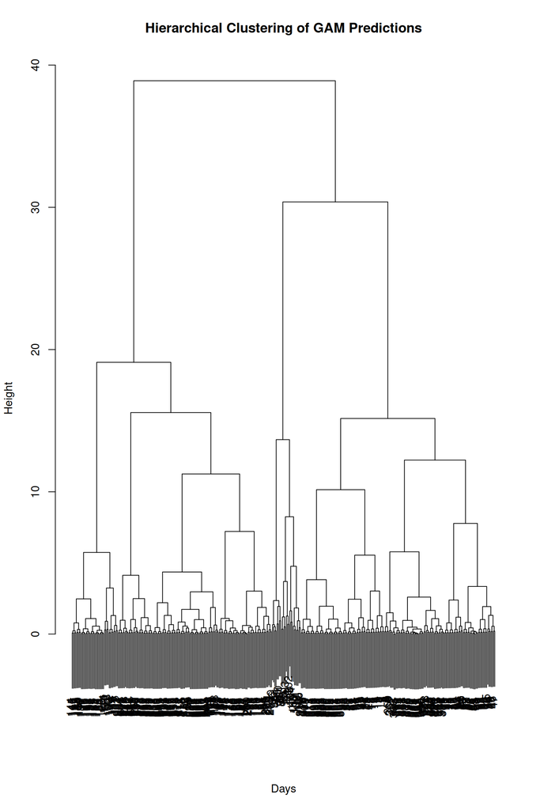

```r
# --- Hierarchical clustering on scaled GAM predictions -----------------------
# Reshape to wide format: one row per day, one column per model
wide_preds <- reshape(
  preds_all2[, c("day_of_year", "fit", "model")],
  timevar   = "model",
  idvar     = "day_of_year",
  direction = "wide"
)

pred_matrix    <- wide_preds[, -1]          # remove day_of_year column
scaled_matrix  <- scale(pred_matrix)        # z-score normalise
dist_matrix    <- dist(scaled_matrix, method = "euclidean")
hc             <- hclust(dist_matrix, method = "ward.D2")

# Visualise dendrogram and optimal cluster number
plot(hc, main = "Hierarchical Clustering of GAM Predictions",
     xlab = "Days", sub = "")
```

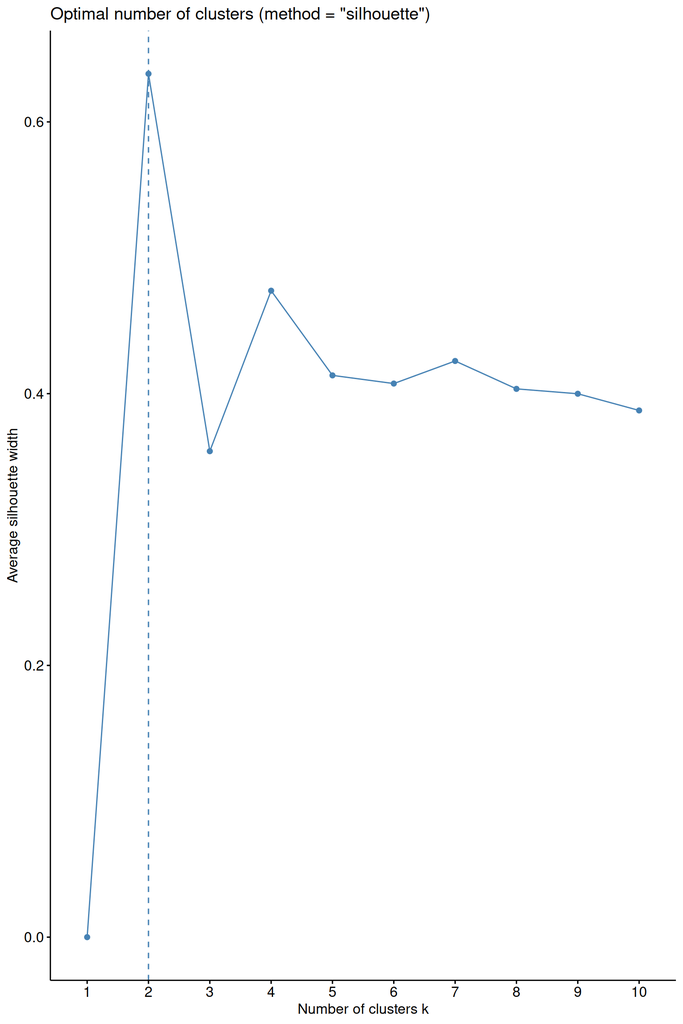

```r
fviz_nbclust(as.matrix(dist_matrix), FUN = hcut,
             method = "silhouette", hc_method = "average")
```

```r
# Cut tree into 2 clusters (summer vs winter regime)
clusters           <- cutree(hc, k = 2)
wide_preds$cluster <- clusters

# Reshape back to long format for plotting; add run_id to track cluster transitions
long_preds <- wide_preds %>%
  pivot_longer(
    cols      = starts_with("fit"),
    names_to  = "variable",
    values_to = "fit"
  ) %>%
  mutate(variable = sub("^fit\\.", "", variable)) %>%
  arrange(variable, day_of_year) %>%
  group_by(variable) %>%
  mutate(run_id = cumsum(cluster != lag(cluster, default = first(cluster)))) %>%
  ungroup()

# Cluster summary table
cluster_summary <- long_preds %>%
  group_by(cluster, variable) %>%
  summarise(
    n_days    = n_distinct(day_of_year),
    mean_fit  = mean(fit, na.rm = TRUE),
    sd_fit    = sd(fit,   na.rm = TRUE),
    start_day = min(day_of_year),
    end_day   = max(day_of_year),
    .groups = "drop"
  ) %>%
  arrange(cluster, variable)
kable(cluster_summary, digits = 2,
      caption = "Summary of cluster properties")
```

Summary of cluster properties

| cluster | variable | n_days | mean_fit | sd_fit | start_day | end_day |
| --- | --- | --- | --- | --- | --- | --- |
| 1 | BD | 193 | 0.90 | 1.88 | 0 | 365 |
| 1 | Bm_Ant_ABZ | 193 | 13.95 | 24.40 | 0 | 365 |
| 1 | Bm_D | 193 | 1.58 | 2.15 | 0 | 365 |
| 1 | centre_of_mass | 193 | 181.25 | 90.95 | 0 | 365 |
| 1 | corrected_thickness | 193 | 10.05 | 4.71 | 0 | 365 |
| 1 | krill_density | 193 | 43.10 | 21.53 | 0 | 365 |
| 2 | BD | 173 | 5.60 | 3.58 | 111 | 283 |
| 2 | Bm_Ant_ABZ | 173 | 3.65 | 7.50 | 111 | 283 |
| 2 | Bm_D | 173 | 0.00 | 0.00 | 111 | 283 |
| 2 | centre_of_mass | 173 | 317.83 | 66.27 | 111 | 283 |
| 2 | corrected_thickness | 173 | 44.05 | 22.61 | 111 | 283 |
| 2 | krill_density | 173 | 12.31 | 12.03 | 111 | 283 |

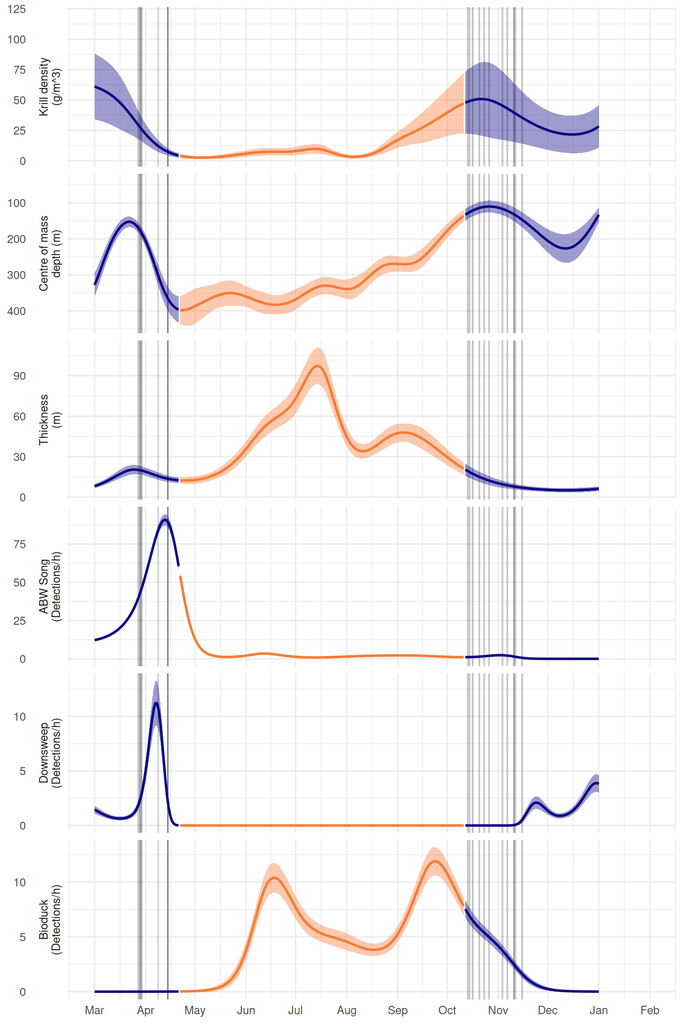

```r
# Attach cluster and run_id to main predictions data frame
preds_all2$cluster <- long_preds$cluster
preds_all2$run_id  <- long_preds$run_id

# --- Plot with cluster colouring ---------------------------------------------
ggplot(data = preds_all2,
       aes(x     = as.Date(day_of_year, origin = "2021-01-01"),
           y     = fit,
           group = interaction(cluster, run_id),
           color = factor(cluster),
           fill  = factor(cluster))) +
  # Predator overlap shading
  geom_rect(
    data        = overlap_ranges,
    inherit.aes = FALSE,
    aes(xmin = as.Date(start - 1, origin = "2021-01-01"),
        xmax = as.Date(end,       origin = "2021-01-01"),
        ymin = -Inf, ymax = Inf),
    fill  = "grey30",
    alpha = 0.3
  ) +
  geom_line(linewidth = 1) +
  geom_ribbon(aes(ymin = lower, ymax = upper), alpha = 0.4, colour = NA) +
  facet_wrap(model ~ .,
             scales         = "free_y",
             nrow           = length(unique(preds_all2$model)),
             strip.position = "left",
             labeller       = my_labels) +
  # Reverse y-axis for centre of mass panel only
  facetted_pos_scales(y = list(
    model == "centre_of_mass" ~ scale_y_reverse()
  )) +
  scale_x_date(date_breaks = "1 month", date_labels = "%b",
               limits = c(as.Date("2021-03-01"), as.Date("2022-01-31"))) +
  scale_color_manual(values = c("1" = "#0D0887", "2" = "#F87C36")) +
  scale_fill_manual( values = c("1" = "#0D0887", "2" = "#F87C36")) +
  ylab(NULL) + xlab(NULL) +
  theme_minimal(base_size = 12) +
  theme(legend.position = "none")
```

## 13. Figure 5 — Diel trends across the year

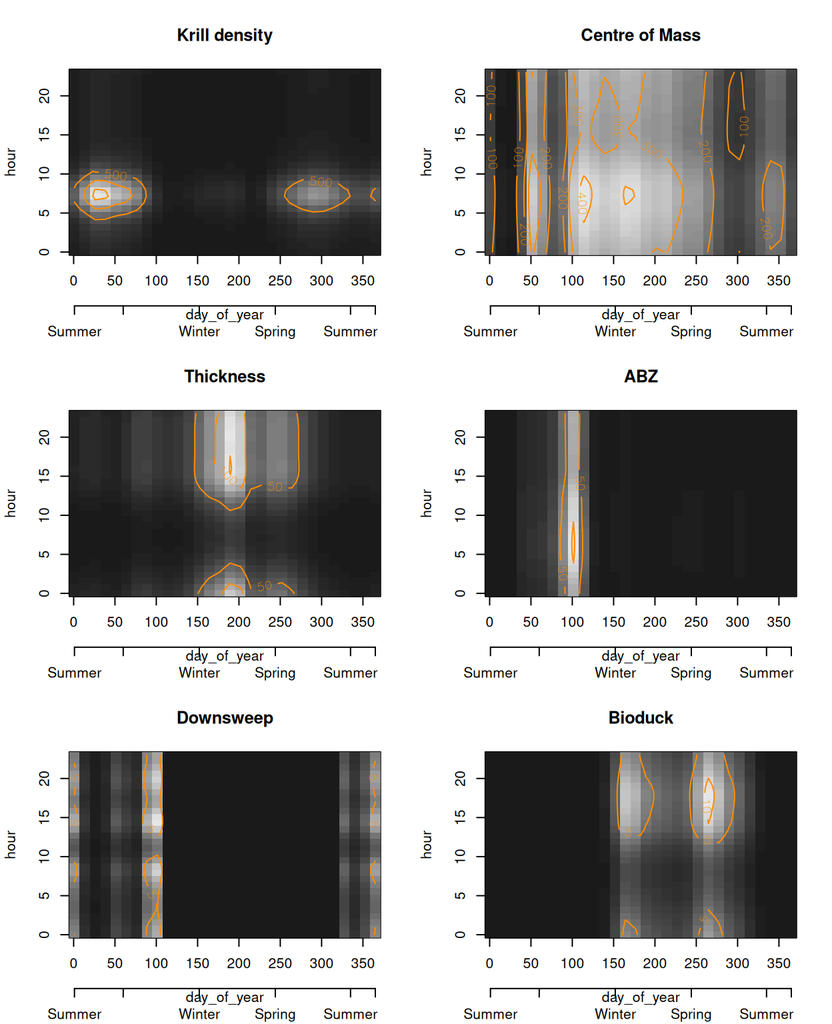

```r
season_starts <- c(1, 60, 152, 244, 335, 365)
season_labels <- c('Summer','Autumn', 'Winter', 'Spring', 'Summer', '-')

par(mfrow=c(3,2))
nLev=3

mgcv::vis.gam(mdensity,view = c('day_of_year','hour'),type='response',
        main='Krill density',
        plot.type='contour', color='gray',contour.col='darkorange',nlevels=nLev)
axis(1, at = season_starts, labels = season_labels, line = 3)

mgcv::vis.gam(mcom,view = c('day_of_year','hour'),type='response',
        main='Centre of Mass',
        plot.type='contour', color='gray',contour.col='darkorange',nlevels=nLev)
axis(1, at = season_starts, labels = season_labels, line = 3)

mgcv::vis.gam(mthickness,view = c('day_of_year','hour'),type='response',
        main='Thickness',
        plot.type='contour', color='gray',contour.col='darkorange',nlevels=nLev)
axis(1, at = season_starts, labels = season_labels, line = 3)

mgcv::vis.gam(m1,view = c('day_of_year','hour'),type='response',
        main='ABZ',
        plot.type='contour',color='gray',contour.col='darkorange',nlevels=nLev)
axis(1, at = season_starts, labels = season_labels, line = 3)

mgcv::vis.gam(m2,view = c('day_of_year','hour'),type='response',
        main='Downsweep',
        plot.type='contour',color='gray',contour.col='darkorange',nlevels=nLev)
axis(1, at = season_starts, labels = season_labels, line = 3)

mgcv::vis.gam(m3,view = c('day_of_year','hour'),type='response',
        main='Bioduck',
        plot.type='contour', color='gray',contour.col='darkorange',nlevels=nLev)
axis(1, at = season_starts, labels = season_labels, line = 3)
```